# Quiz 02

Matheus Cardoso

Jun 12, 2020

# Q1

For this quiz we will be using several R packages. R package versions change over time, the right answers have been checked using the following versions of the packages.

AppliedPredictiveModeling: v1.1.6

caret: v6.0.47

ElemStatLearn: v2012.04-0

pgmm: v1.1

rpart: v4.1.8

If you aren’t using these versions of the packages, your answers may not exactly match the right answer, but hopefully should be close.

Load the cell segmentation data from the AppliedPredictiveModeling package using the commands:

```r
library(AppliedPredictiveModeling)
data(segmentationOriginal)
library(caret)
```

1. Subset the data to a training set and testing set based on the Case variable in the data set.
2. Set the seed to 125 and fit a CART model with the rpart method using all predictor variables and default caret settings.
3. In the final model what would be the final model prediction for cases with the following variable values:
   1. TotalIntench2 = 23,000; FiberWidthCh1 = 10; PerimStatusCh1=2
   2. TotalIntench2 = 50,000; FiberWidthCh1 = 10;VarIntenCh4 = 100
   3. TotalIntench2 = 57,000; FiberWidthCh1 = 8;VarIntenCh4 = 100
   4. FiberWidthCh1 = 8;VarIntenCh4 = 100; PerimStatusCh1=2

## A1

```r
set.seed(125)

names(segmentationOriginal)
```

```
##   [1] "Cell"                          "Case"
##   [3] "Class"                         "AngleCh1"
##   [5] "AngleStatusCh1"                "AreaCh1"
##   [7] "AreaStatusCh1"                 "AvgIntenCh1"
##   [9] "AvgIntenCh2"                   "AvgIntenCh3"
##  [11] "AvgIntenCh4"                   "AvgIntenStatusCh1"
##  [13] "AvgIntenStatusCh2"             "AvgIntenStatusCh3"
##  [15] "AvgIntenStatusCh4"             "ConvexHullAreaRatioCh1"
##  [17] "ConvexHullAreaRatioStatusCh1"  "ConvexHullPerimRatioCh1"
##  [19] "ConvexHullPerimRatioStatusCh1" "DiffIntenDensityCh1"
##  [21] "DiffIntenDensityCh3"           "DiffIntenDensityCh4"
##  [23] "DiffIntenDensityStatusCh1"     "DiffIntenDensityStatusCh3"
##  [25] "DiffIntenDensityStatusCh4"     "EntropyIntenCh1"
##  [27] "EntropyIntenCh3"               "EntropyIntenCh4"
##  [29] "EntropyIntenStatusCh1"         "EntropyIntenStatusCh3"
```

[output cut: 45 more lines]

```r
dim(segmentationOriginal)
```

```
## [1] 2019  119
```

```r
inTrain <- createDataPartition(segmentationOriginal$Case, p = .7, list = F)
training <- segmentationOriginal[ inTrain, ]
testing  <- segmentationOriginal[-inTrain, ]

a1_model <- train(Case ~ ., data = training, method = "rpart")
a1_model$finalModel
```

```
## n= 1414
##
## node), split, n, loss, yval, (yprob)
##       * denotes terminal node
##
## 1) root 1414 707 Test (0.5000000 0.5000000)
##   2) LengthCh1< 36.01498 1087 513 Test (0.5280589 0.4719411)
##     4) KurtIntenCh1>=-0.5226197 800 348 Test (0.5650000 0.4350000) *
##     5) KurtIntenCh1< -0.5226197 287 122 Train (0.4250871 0.5749129) *
##   3) LengthCh1>=36.01498 327 133 Train (0.4067278 0.5932722) *
```

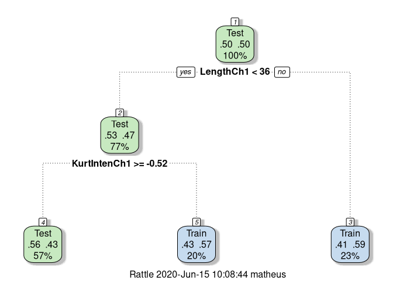

```r
fancyRpartPlot(a1_model$finalModel)
```

# Q2

If K is small in a K-fold cross validation is the bias in the estimate of out-of-sample (test set) accuracy smaller or bigger? If K is small is the variance in the estimate of out-of-sample (test set) accuracy smaller or bigger. Is K large or small in leave one out cross validation?

## A2

The bias is larger and the variance is smaller. Under leave one out cross validation K is equal to the sample size.

# Q3

Load the olive oil data using the commands:

```r
library(pgmm)
data(olive)
olive = olive[,-1]
```

(NOTE: If you have trouble installing the pgmm package, you can download the -code-olive-/code- dataset here: olive_data.zip. After unzipping the archive, you can load the file using the -code-load()-/code- function in R.)

These data contain information on 572 different Italian olive oils from multiple regions in Italy. Fit a classification tree where Area is the outcome variable. Then predict the value of area for the following data frame using the tree command with all defaults

```r
newdata = as.data.frame(t(colMeans(olive)))

str(newdata)
```

```
## 'data.frame':    1 obs. of  9 variables:
##  $ Area       : num 4.6
##  $ Palmitic   : num 1232
##  $ Palmitoleic: num 126
##  $ Stearic    : num 229
##  $ Oleic      : num 7312
##  $ Linoleic   : num 981
##  $ Linolenic  : num 31.9
##  $ Arachidic  : num 58.1
##  $ Eicosenoic : num 16.3
```

```r
a2_model <- train(Area ~ ., data = olive, method = "rpart")
predict(a2_model)
```

[output not shown]

[output cut: 89 more lines]

[output not shown]

## A3

# Q4

Load the Alzheimer’s disease data using the commands:

```r
library(caret)
library(AppliedPredictiveModeling)
set.seed(3433)
data(AlzheimerDisease)
adData = data.frame(diagnosis,predictors)
inTrain = createDataPartition(adData$diagnosis, p = 3/4)[[1]]
training = adData[ inTrain,]
testing = adData[-inTrain,]
```

Find all the predictor variables in the training set that begin with IL. Perform principal components on these variables with the preProcess() function from the caret package. Calculate the number of principal components needed to capture 90% of the variance. How many are there?

```r
str(training)
```

```
## 'data.frame':    251 obs. of  131 variables:
##  $ diagnosis                       : Factor w/ 2 levels "Impaired","Control": 2 2 2 2 1 2 2 2 1 1 ...
##  $ ACE_CD143_Angiotensin_Converti  : num  2.003 1.521 1.681 2.401 0.431 ...
##  $ ACTH_Adrenocorticotropic_Hormon : num  -1.386 -1.715 -1.609 -0.968 -1.273 ...
##  $ AXL                             : num  1.098 -0.145 0.683 0.191 -0.222 ...
##  $ Adiponectin                     : num  -5.36 -5.81 -5.12 -4.78 -5.22 ...
##  $ Alpha_1_Antichymotrypsin        : num  1.74 1.19 1.28 2.13 1.31 ...
##  $ Alpha_1_Antitrypsin             : num  -12.6 -13.6 -15.5 -11.1 -12.1 ...
##  $ Alpha_1_Microglobulin           : num  -2.58 -2.88 -3.17 -2.34 -2.55 ...
##  $ Alpha_2_Macroglobulin           : num  -72.7 -136.5 -98.4 -144.9 -154.6 ...
##  $ Angiopoietin_2_ANG_2            : num  1.0647 0.8329 0.9163 0.9555 -0.0513 ...
##  $ Angiotensinogen                 : num  2.51 1.98 2.38 2.86 2.52 ...
##  $ Apolipoprotein_A_IV             : num  -1.43 -1.66 -2.12 -1.17 -1.39 ...
##  $ Apolipoprotein_A1               : num  -7.4 -7.68 -8.05 -6.73 -7.4 ...
##  $ Apolipoprotein_A2               : num  -0.2614 -0.6539 -1.2379 0.0953 -0.2744 ...
```

[output cut: 86 more lines]

```r
names(training)
```

```
##   [1] "diagnosis"                        "ACE_CD143_Angiotensin_Converti"
##   [3] "ACTH_Adrenocorticotropic_Hormon"  "AXL"
##   [5] "Adiponectin"                      "Alpha_1_Antichymotrypsin"
##   [7] "Alpha_1_Antitrypsin"              "Alpha_1_Microglobulin"
##   [9] "Alpha_2_Macroglobulin"            "Angiopoietin_2_ANG_2"
##  [11] "Angiotensinogen"                  "Apolipoprotein_A_IV"
##  [13] "Apolipoprotein_A1"                "Apolipoprotein_A2"
##  [15] "Apolipoprotein_B"                 "Apolipoprotein_CI"
##  [17] "Apolipoprotein_CIII"              "Apolipoprotein_D"
##  [19] "Apolipoprotein_E"                 "Apolipoprotein_H"
##  [21] "B_Lymphocyte_Chemoattractant_BL"  "BMP_6"
##  [23] "Beta_2_Microglobulin"             "Betacellulin"
##  [25] "C_Reactive_Protein"               "CD40"
##  [27] "CD5L"                             "Calbindin"
##  [29] "Calcitonin"                       "CgA"
```

[output cut: 51 more lines]

```r
training_subset <- training %>% select(starts_with("IL"))
names(training_subset)
```

```
##  [1] "IL_11"         "IL_13"         "IL_16"         "IL_17E"
##  [5] "IL_1alpha"     "IL_3"          "IL_4"          "IL_5"
##  [9] "IL_6"          "IL_6_Receptor" "IL_7"          "IL_8"
```

```r
data <- preProcess(
            training_subset,
            method = "pca",
            thresh = 0.9
            )
data
```

```
## Created from 251 samples and 12 variables
##
## Pre-processing:
##   - centered (12)
##   - ignored (0)
##   - principal component signal extraction (12)
##   - scaled (12)
##
## PCA needed 9 components to capture 90 percent of the variance
```

## A4

9

# Q5

Load the Alzheimer’s disease data using the commands:

```r
library(caret)
library(AppliedPredictiveModeling)
set.seed(3433)
data(AlzheimerDisease)
adData = data.frame(diagnosis,predictors)
inTrain = createDataPartition(adData$diagnosis, p = 3/4)[[1]]
training = adData[ inTrain,]
testing = adData[-inTrain,]
```

Create a training data set consisting of only the predictors with variable names beginning with IL and the diagnosis. Build two predictive models, one using the predictors as they are and one using PCA with principal components explaining 80% of the variance in the predictors. Use method=“glm” in the train function.

What is the accuracy of each method in the test set? Which is more accurate?

```r
str(training)
```

```
## 'data.frame':    251 obs. of  131 variables:
##  $ diagnosis                       : Factor w/ 2 levels "Impaired","Control": 2 2 2 2 1 2 2 2 1 1 ...
##  $ ACE_CD143_Angiotensin_Converti  : num  2.003 1.521 1.681 2.401 0.431 ...
##  $ ACTH_Adrenocorticotropic_Hormon : num  -1.386 -1.715 -1.609 -0.968 -1.273 ...
##  $ AXL                             : num  1.098 -0.145 0.683 0.191 -0.222 ...
##  $ Adiponectin                     : num  -5.36 -5.81 -5.12 -4.78 -5.22 ...
##  $ Alpha_1_Antichymotrypsin        : num  1.74 1.19 1.28 2.13 1.31 ...
##  $ Alpha_1_Antitrypsin             : num  -12.6 -13.6 -15.5 -11.1 -12.1 ...
##  $ Alpha_1_Microglobulin           : num  -2.58 -2.88 -3.17 -2.34 -2.55 ...
##  $ Alpha_2_Macroglobulin           : num  -72.7 -136.5 -98.4 -144.9 -154.6 ...
##  $ Angiopoietin_2_ANG_2            : num  1.0647 0.8329 0.9163 0.9555 -0.0513 ...
##  $ Angiotensinogen                 : num  2.51 1.98 2.38 2.86 2.52 ...
##  $ Apolipoprotein_A_IV             : num  -1.43 -1.66 -2.12 -1.17 -1.39 ...
##  $ Apolipoprotein_A1               : num  -7.4 -7.68 -8.05 -6.73 -7.4 ...
##  $ Apolipoprotein_A2               : num  -0.2614 -0.6539 -1.2379 0.0953 -0.2744 ...
```

[output cut: 86 more lines]

```r
names(training)
```

```
##   [1] "diagnosis"                        "ACE_CD143_Angiotensin_Converti"
##   [3] "ACTH_Adrenocorticotropic_Hormon"  "AXL"
##   [5] "Adiponectin"                      "Alpha_1_Antichymotrypsin"
##   [7] "Alpha_1_Antitrypsin"              "Alpha_1_Microglobulin"
##   [9] "Alpha_2_Macroglobulin"            "Angiopoietin_2_ANG_2"
##  [11] "Angiotensinogen"                  "Apolipoprotein_A_IV"
##  [13] "Apolipoprotein_A1"                "Apolipoprotein_A2"
##  [15] "Apolipoprotein_B"                 "Apolipoprotein_CI"
##  [17] "Apolipoprotein_CIII"              "Apolipoprotein_D"
##  [19] "Apolipoprotein_E"                 "Apolipoprotein_H"
##  [21] "B_Lymphocyte_Chemoattractant_BL"  "BMP_6"
##  [23] "Beta_2_Microglobulin"             "Betacellulin"
##  [25] "C_Reactive_Protein"               "CD40"
##  [27] "CD5L"                             "Calbindin"
##  [29] "Calcitonin"                       "CgA"
```

[output cut: 51 more lines]

```r
training_subset <- training %>%
                        select(starts_with("IL") | "diagnosis")

testing_subset <- testing %>%
                        select(starts_with("IL") | "diagnosis")

names(training_subset)
```

```
##  [1] "IL_11"         "IL_13"         "IL_16"         "IL_17E"
##  [5] "IL_1alpha"     "IL_3"          "IL_4"          "IL_5"
##  [9] "IL_6"          "IL_6_Receptor" "IL_7"          "IL_8"
## [13] "diagnosis"
```

```r
names(testing_subset)
```

```
##  [1] "IL_11"         "IL_13"         "IL_16"         "IL_17E"
##  [5] "IL_1alpha"     "IL_3"          "IL_4"          "IL_5"
##  [9] "IL_6"          "IL_6_Receptor" "IL_7"          "IL_8"
## [13] "diagnosis"
```

```r
# model Non-PCA
mod1 <- train(
            diagnosis ~ .,
            data = training_subset,
            method = "glm"
            )

pred1 <- predict(mod1, testing_subset)

result1 <- confusionMatrix(pred1, testing_subset$diagnosis)

# model PCA
mod2 <- train(
            diagnosis ~ .,
            data = training_subset,
            trControl = trainControl(preProcOptions = list(thresh = 0.8)),
            preProcess = "pca",
            method = "glm"
            )

pred2 <- predict(mod2, testing_subset)

result2 <- confusionMatrix(pred2, testing_subset$diagnosis)

result1
```

```
## Confusion Matrix and Statistics
##
##           Reference
## Prediction Impaired Control
##   Impaired        4       2
##   Control        18      58
##
##                Accuracy : 0.7561
##                  95% CI : (0.6488, 0.8442)
##     No Information Rate : 0.7317
##     P-Value [Acc > NIR] : 0.3606488
##
##                   Kappa : 0.1929
##
##  Mcnemar's Test P-Value : 0.0007962
##
##             Sensitivity : 0.18182
##             Specificity : 0.96667
##          Pos Pred Value : 0.66667
##          Neg Pred Value : 0.76316
##              Prevalence : 0.26829
##          Detection Rate : 0.04878
##    Detection Prevalence : 0.07317
##       Balanced Accuracy : 0.57424
##
##        'Positive' Class : Impaired
##
```

```r
result2
```

```
## Confusion Matrix and Statistics
##
##           Reference
## Prediction Impaired Control
##   Impaired        1       2
##   Control        21      58
##
##                Accuracy : 0.7195
##                  95% CI : (0.6094, 0.8132)
##     No Information Rate : 0.7317
##     P-Value [Acc > NIR] : 0.6517805
##
##                   Kappa : 0.0167
##
##  Mcnemar's Test P-Value : 0.0001746
##
##             Sensitivity : 0.04545
##             Specificity : 0.96667
##          Pos Pred Value : 0.33333
##          Neg Pred Value : 0.73418
##              Prevalence : 0.26829
##          Detection Rate : 0.01220
##    Detection Prevalence : 0.03659
##       Balanced Accuracy : 0.50606
##
##        'Positive' Class : Impaired
##
```

## A5

I can’t make it work. this exercise will be lacking. :/